# RMarkdown, Quarto, and Reproducible research

Author

Mark D. Own

# Introduction & Motivation

Reproducible research is essential for modern data science. By combining code, results, and narrative in a single document, we can ensure that analyses are transparent and automatically updated when data or methods change.

This document demonstrates:

- The basics of Quarto (the next generation of R Markdown)
- How to use code chunks and inline code
- Customizing chunk options
- Rendering documents from the command line
- Integrating tidyverse data manipulation and ggplot2 visualizations
- See [Quarto](https://quarto.org/) for more information on Quarto, including installation instructions and a comprehensive guide to all features.
- Or [Quarto for R](https://r4ds.hadley.nz/quarto.html) for more information on using Quarto with R.

# Intended Quarto use

- Quarto is a next-generation R Markdown that is designed to be a more powerful and flexible tool for creating dynamic documents, reports, and presentations.
- Sharing your R analyses with others.
- Environment for data science and lab notebooks where you capture not only the code but also the data, results, and narrative in a single document.

# Quarto/ RMarkdown document structure

- YAML header (optionally)
  - surrounded by `---`
  - contains metadata about the document, header, author, …
- Markdown text
  - plain text
  - contains narrative, explanations, and descriptions
  - can include formatting (headings, lists, links, images, etc.)
- Code **chunks**
  - surrounded by `` ```{r} ``` ``
  - contains R code
- Inline code
  - surrounded by `r` and backticks
  - used to include the results of R code in the text

# RStudio IDE

- Visual editor

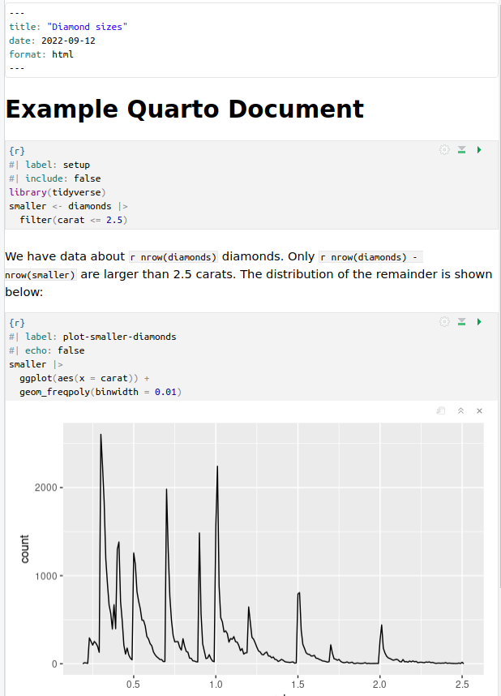

- Plain text editor

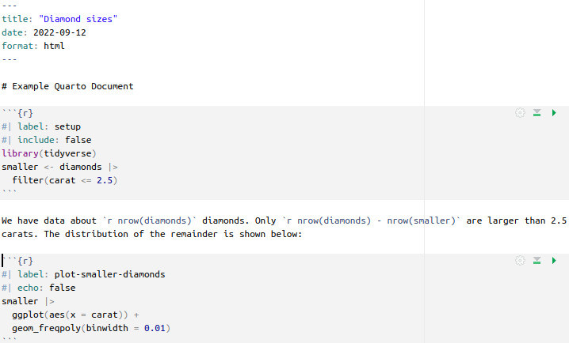

# R Chunks

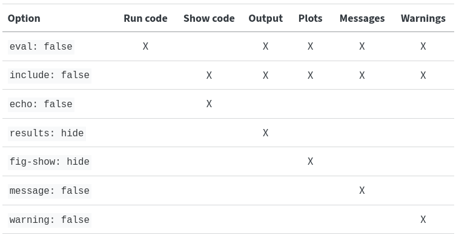

(source: [r4ds](https://r4ds.hadley.nz/quarto.html))

## Simple chuck with code evalated and results shown

```r
# using default options
# this chunk runs the code and shows the results
x <- 1:10
y <- x^2
print(y)
```

```
 [1]   1   4   9  16  25  36  49  64  81 100
```

## Chunk with code not evaluated

```r
# this is suitable for showing code examples
print(z)
```

## Chunk with code not show but evaluated and results shown

```
 [1]   1   4   9  16  25  36  49  64  81 100
```

# Plotting

## Simple plot with code and results shown

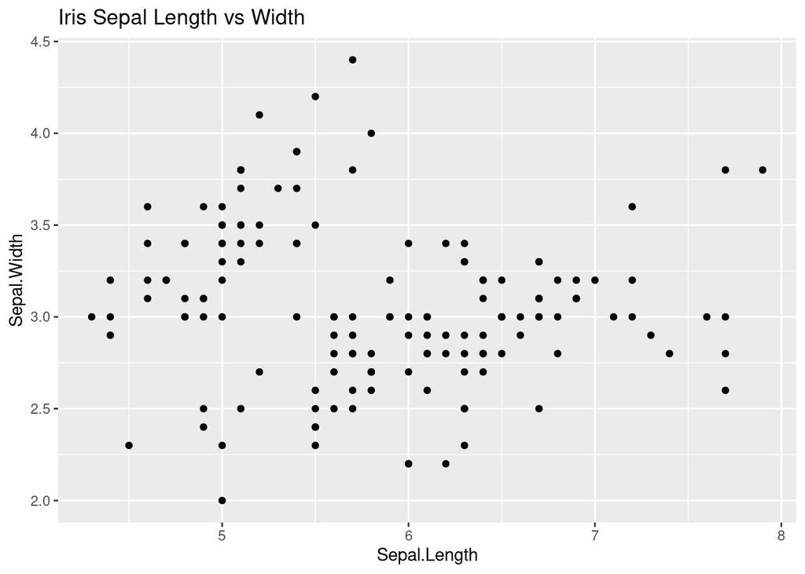

```r
ggplot(iris, aes(x = Sepal.Length, y = Sepal.Width)) +
  geom_point() +
  labs(title = "Iris Sepal Length vs Width")
```

## Chunk with figure, captions and code not shown

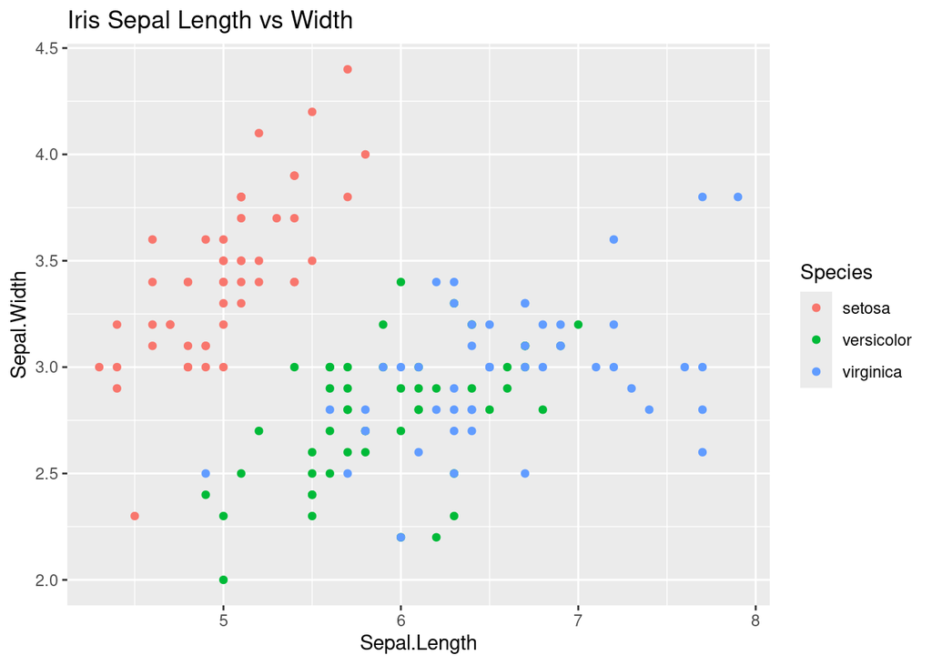

**Fig.1** Iris Sepal Length vs Width, by species

## Multiple plots in one chunk

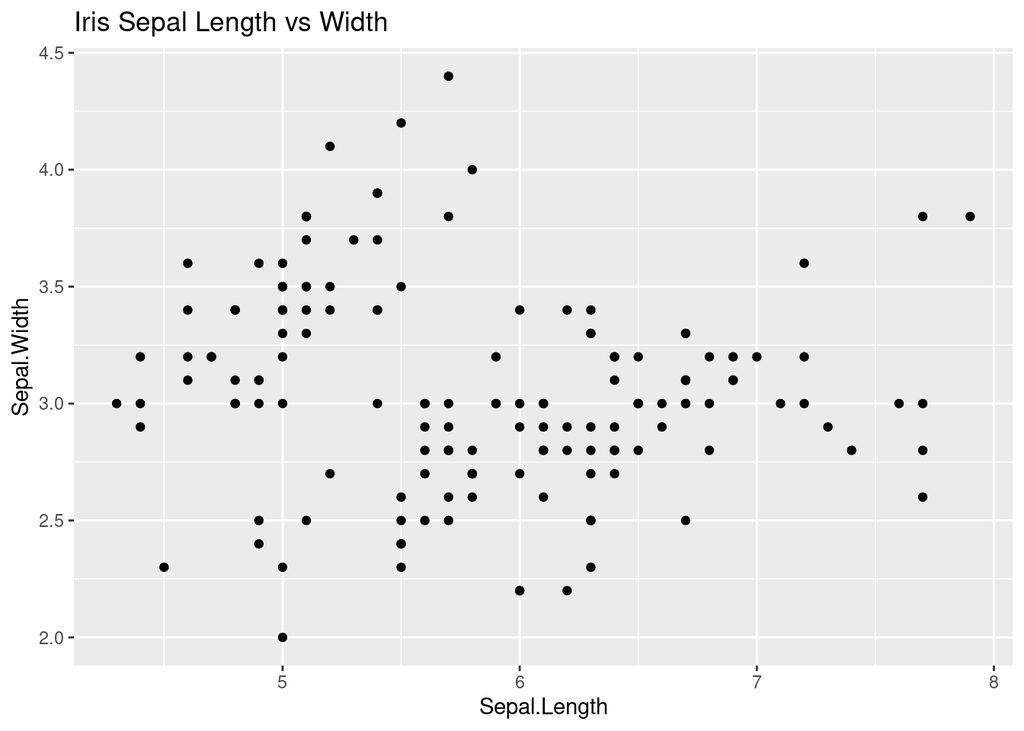

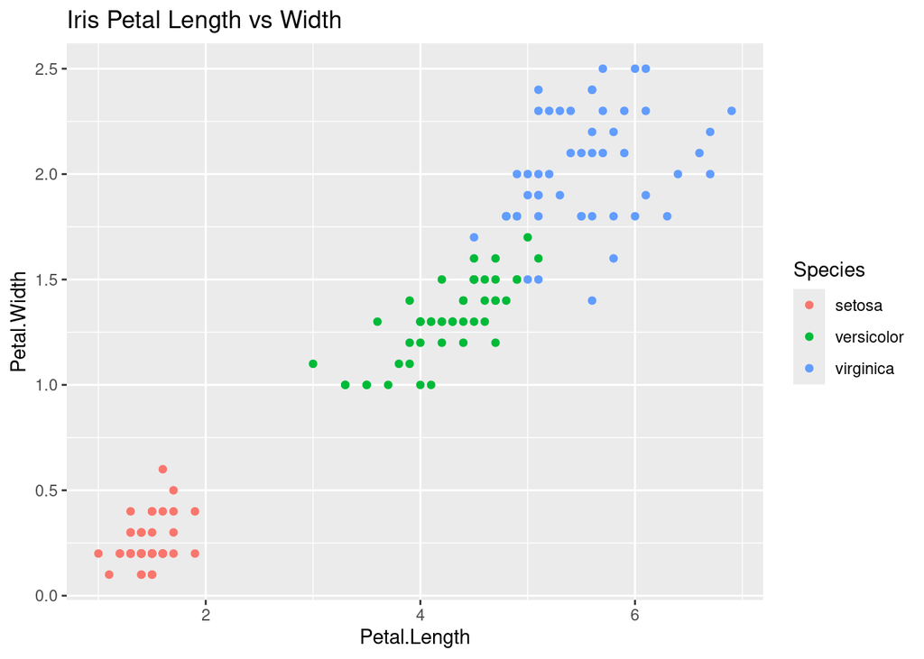

## Mutiple plots side by side

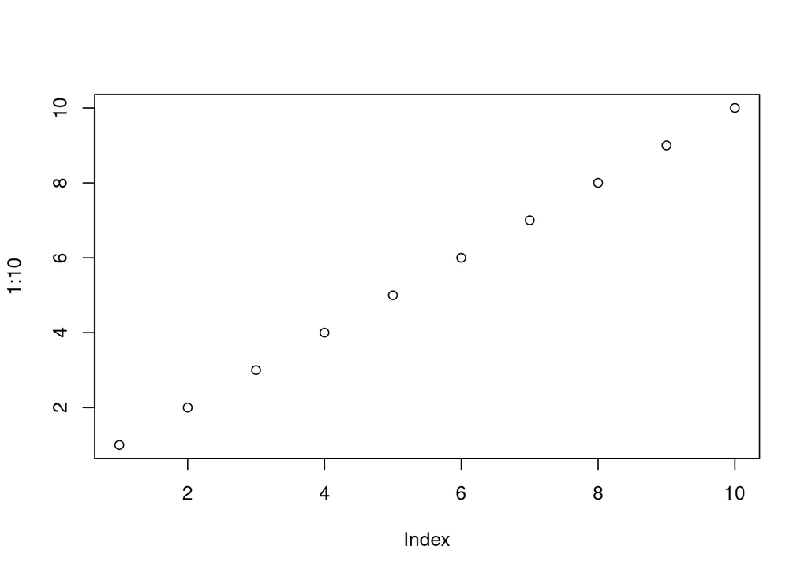

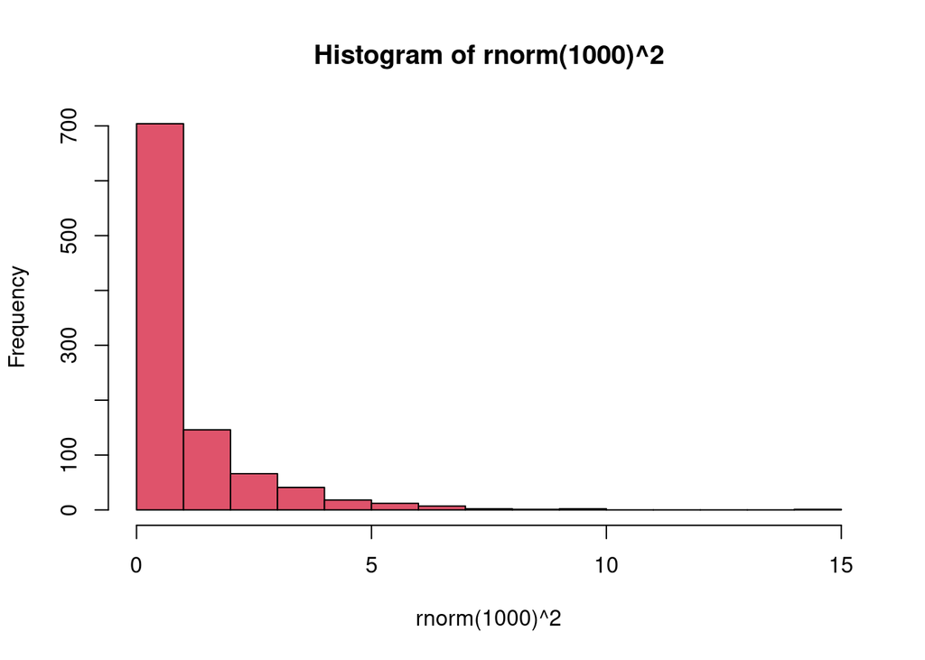

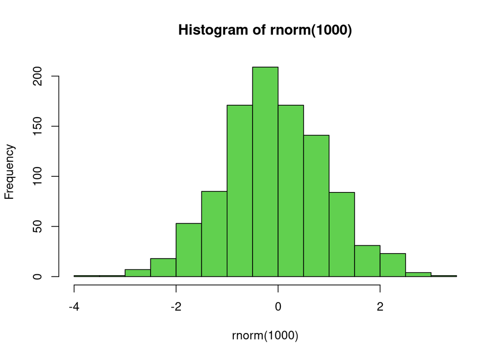

```r
plot(1:10)
hist(rnorm(1000)^2, col=2)
hist(rnorm(1000), col=3)
```

## Inline code

- Inline code is used to include the results of R code in the text.
- It is surrounded by backticks and the letter `r`

For example, previously we created a variable `x` and assigned it the value `1:10`. We can include the value of `x` in the text. The value of `x` is 1, 2, 3, 4, 5, 6, 7, 8, 9, 10 and the length of `x` is 10.

# Printing tables

One of the strengths of RMarkdown and Quarto is the ability to neatly print tables using the `kable()` function from the `knitr` package. The `kable()` function converts a data frame (or tibble) into a simple, nicely formatted table in the final document.

## Printing without `kable`

```r
# print part of the iris dataset
iris[1:5, ]
```

```
  Sepal.Length Sepal.Width Petal.Length Petal.Width Species
1          5.1         3.5          1.4         0.2  setosa
2          4.9         3.0          1.4         0.2  setosa
3          4.7         3.2          1.3         0.2  setosa
4          4.6         3.1          1.5         0.2  setosa
5          5.0         3.6          1.4         0.2  setosa
```

The table above is printed without any formatting.

## Printing with `kable`

```r
library(knitr)
kable(iris[1:5, ])
```

| Sepal.Length | Sepal.Width | Petal.Length | Petal.Width | Species |
| --- | --- | --- | --- | --- |
| 5.1 | 3.5 | 1.4 | 0.2 | setosa |
| 4.9 | 3.0 | 1.4 | 0.2 | setosa |
| 4.7 | 3.2 | 1.3 | 0.2 | setosa |
| 4.6 | 3.1 | 1.5 | 0.2 | setosa |
| 5.0 | 3.6 | 1.4 | 0.2 | setosa |

## Formatting tables with `kable`

### Formating numeric columns

```r
# Create a sample data frame
df_example <- data.frame(
  Value = c(1234.5678, 98765.4321, 1234567.89),
  Rate  = c(0.12345, 0.98765, 0.54321)
)

# Print the table using kable()
# 'digits' sets the number of decimals,
# 'format.args' specifies formatting options for numeric values.
knitr::kable(
  df_example,
  digits = 2,
  format.args = list(big.mark = ",", decimal.mark = "."),
  caption = "Table 1: Sample Data with Formatted Numeric Columns"
)
```

Table 1: Sample Data with Formatted Numeric Columns

| Value | Rate |
| --- | --- |
| 1,234.57 | 0.12 |
| 98,765.43 | 0.99 |
| 1,234,567.89 | 0.54 |

### Centering columns

```r
# Center-align all columns by passing a vector of "c"
knitr::kable(
  df_example,
  align = rep("c", ncol(df_example)),
  caption = "Table 2: All Columns Center-Aligned"
)
```

Table 2: All Columns Center-Aligned

| Value | Rate |
| --- | --- |
| 1234.568 | 0.12345 |
| 98765.432 | 0.98765 |
| 1234567.890 | 0.54321 |

### Different alignments

```r
# Left-align the first column and right-align the second column
knitr::kable(
  df_example,
  align = c("l", "r"),
  digits = 2,
  format.args = list(big.mark = ",", decimal.mark = "."),
  caption = "Table 3: Different Column Alignments"
)
```

Table 3: Different Column Alignments

| Value | Rate |
| --- | --- |
| 1,234.57 | 0.12 |
| 98,765.43 | 0.99 |
| 1,234,567.89 | 0.54 |

# Cashing calculations

- Normally, every time you run a chunk, the code is executed and the results are shown.
- If the code takes a long time to run, you can use the `cache` option to save the results of the chunk so that it doesn’t have to be re-run every time.
- The cashe option can be set either in the YAML header or in the chunk options.

Yaml options:

```yaml
---
title: "My Document"
execute:
  cache: true
---
```

- Chunk options will be applied to that chunk only

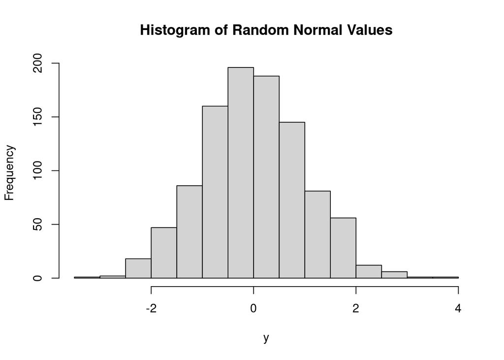

```r
# code with long calculation
Sys.sleep(5) # simulate a long calculation
y <- rnorm(1000)
hist(y, main = "Histogram of Random Normal Values")
```